# My Permutaion Analysis

William Miller

```r
# Play the chunk above and this one to get the data into your Console
View(Friendly)
?Friendly
```

## Background

The idea behind a permutation analysis is to see how close our resulting test statistic is to being rare and uncommon, or pretty standard. The way in which we do this is by taking the data and while keeping the `Y` variables constant, scrambaling around the `X` variables. Then the same test is run. We do this 2000 times, and then graph the gather test statistics to see where our original one lies. If it is close to the center of the bell curve then is it common and not necesarilly significant. If it is far away, and more of an outlier than we can see that it was a good test and the result was special and significant.

The following analysis was previously done, but is now being reworked with a permutation test run in it. The originally recieved p-value will be shown with its resulting test statistic, and then compared to the results of the permutation.

## Recalling Words Analysis

Many teachers and other educators are interested in understanding how to best deliver new content to students. In general, they have two choices of how to do this.

1. The Meshed Approach
   - Deliver new content while simultaneously reviewing previously understood content.
2. The Before Approach
   - Deliver new content after fully reviewing previously understood content.

A study was performed to determine whether the *Meshed* or *Before* approaches to delivering content had any positive benefits on memory recall.

The purpose of this analysis is to compare the data between the Before and the Meshed approaches. We want to know if there is any differnce between the approches, and if their is, than to know which approach is better.

## Analysis

**Hypothesis**

$$H_0: \text{Median of the Differences } = 0$$
$$H_a: \text{Median of the Differences } \neq 0$$
$$\alpha = .05$$

**Boxplot**

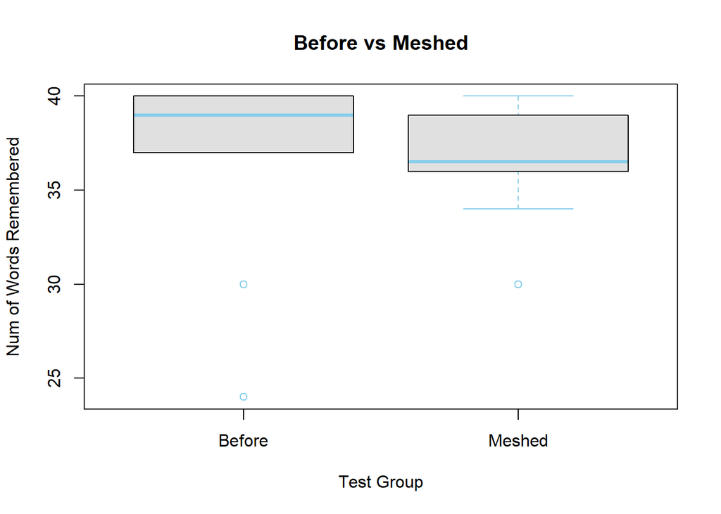

```r
set3 <- subset(Friendly, condition %in% "Before" | condition %in% "Meshed" | condition != "SFR")
set3 <- droplevels(subset(Friendly, condition %in% "Before" | condition %in% "Meshed" | condition != "SFR"))
boxplot(correct ~ condition, data = set3, whiskcol = "skyblue", staplecol = "skyblue", col = "grey88", medcol = "skyblue", pointscol = "skyblue", outcol = "skyblue", xlab = "Test Group", ylab = "Num of Words Remembered", main = "Before vs Meshed")
```

The above graph is a boxplot of the median for both the Before and the Meshed groups. This plot shows us that they do appear to have different means, but the data is very close to eachother. Just from looking at this graph we may be tempted to say that the Before condition is better, however due to outliers and the proximity of the data we will need to preform more testing.

**Wilcoxon Test**

To help us answer our hypothesis and questions we will need to preform a wilcoxon test. This test will compaire the medians for us.

```r
set1 <- droplevels(subset(Friendly, condition == "Before" | condition == "Meshed"))

pander(wilcox.test(correct ~ condition, data = set1, mu = 0, alternative = "two.sided", conf.level = .95))
```

Wilcoxon rank sum test with continuity correction: `correct` by `condition`

| Test statistic | P value | Alternative hypothesis |
| --- | --- | --- |
| 62 | 0.378 | two.sided |

**Permutation of Test**

The following is the permutation test, as discussed above in the `Background` section.

```r
#Permutation
myTest <- wilcox.test(correct ~ condition, data = set1, mu = 0)
observedTestStat <- myTest$statistic

N <- 2000
permutedTestStats <- rep(NA, N)
for (i in 1:N){
  permutedData <- sample(set1$correct)
  permutedTest <- wilcox.test(permutedData ~ condition, data = set1, mu = 0)
  permutedTestStats[i] <- permutedTest$statistic
}
```

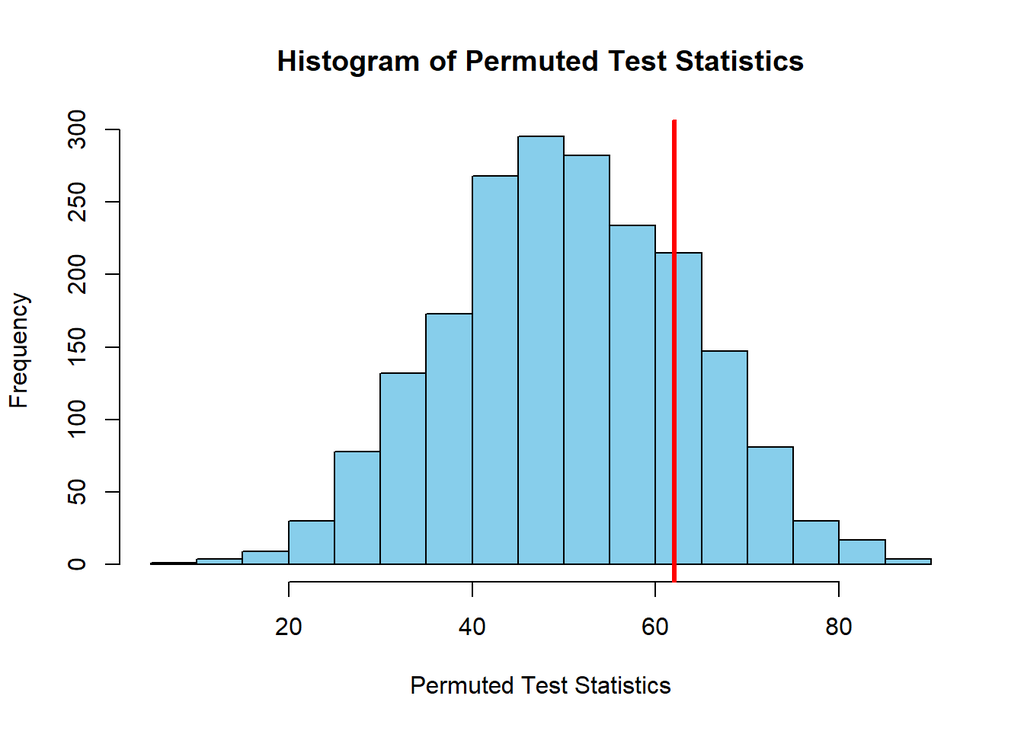

```r
hist(permutedTestStats, col = "skyblue", xlab = "Permuted Test Statistics", main = "Histogram of Permuted Test Statistics")
abline(v = observedTestStat, col = "red", lwd = 3)
```

**Greater-Than p-Value:**

```r
#Greater-Than p-value: Not the correct one in this case
xx1 <- sum(permutedTestStats >= observedTestStat)/N
```

$$\text{The calculated p-Value for Greater-Than is}: \text{ p} = 0.213$$

**Less-Than p-Value:**

```r
# Less-Than p-value: This is the corret one
xx <- sum(permutedTestStats <= observedTestStat)/N
```

$$\text{The calculated p-Value forLess-Than is}: \text{ p} = 0.8025$$

**Two-Sided p-Value**

```r
# Two-Sided p-value
xx2 <- 2*sum(permutedTestStats >= observedTestStat)/N
```

$$\text{The calculated p-Value for Two-Sided is}: \text{ p} = 0.426$$
The two-sided p-Values recieved from the permutation test will replace the one we originally gathered, this being a more accurate p-Value for the test.